# Prediction of Exercise Execution Quality Using Accelerometer Data

Paddy McPhillips

21 January 2019

### Introduction

Today there are many personal activity tracker devices such as the Fitbit, Samsung Gear Fit, Jawbone Up, etc. that capture a large amount of data about personal activity. People regularly quantify how much of a particular activity they do, but they rarely quantify how well they do it. In this investigation, data from accelerometers on the belt, forearm, arm, and dumbell is used from 6 participants to predict the manner in which the barbell lifts were being carried out by them.  
The data for this analysis was kindly shared by [Groupware@LES](http://groupware.les.inf.puc-rio.br/) and can be found along with more background information [here](http://web.archive.org/web/20161224072740/http:/groupware.les.inf.puc-rio.br/har).

#### Data Analysis.

Some analysis of the data show the some of the columns appeared to have some post processing carried out on a per window basis. These variables were excluded from the analysis. There also appeared to be some aggregate values calculated where ‘new_window’ = ‘yes’.  
In order to determine this analysis was carried out to see NA, blank and #DIV/0 entries. Columns with 95% values were ruled out.  
The first 7x columns oc data were also exclued as these included participant names, time data and window label which were not used in this prediction modelling exercise. The resulting training dataset consisted of 19216 rows with 53 variables.

```r
        ## Load the training data
                # HAR_train <- read.csv("./Data/pml-training.csv")      # Load in the raw data before any cleaning
                ## Take a quick look at the data
                        # dim(HAR_train)
                        # summary(HAR_train)    # This data set has a lot of variables so not really useful
                        # head(HAR_train,20)    # Take a look at a few rows of this data
                        # str(HAR_train)

                # ## Check to see how many NAs etc. are in each column
                        # na_count <-sapply(HAR_train, function(y) sum(length(which(is.na(y)))))
                        # na_count <- data.frame(na_count)
                        # blank_count <- sapply(HAR_train, function(y) sum(y=="",na.rm=FALSE))
                        # blank_count <- data.frame(blank_count)
                        # space_count <- sapply(HAR_train, function(y) sum(y==" ",na.rm=FALSE))
                        # space_count <- data.frame(space_count)
                        # div0_count <- sapply(HAR_train, function(y) sum(y=="#DIV/0!",na.rm=FALSE))
                        # div0_count <- data.frame(div0_count)
                        # isNA_count<-cbind(na_count,blank_count,div0_count,space_count)
                        # dim(isNA_count)

                # ## Check to see which columns have more that 95% NAs
                #         clean_NA_cols <- colSums(is.na(HAR_train))/nrow(HAR_train) < 0.98
                #         clean_HAR_train <- HAR_train[,clean_NA_cols]

                ## Clean data
                        # After inspecting data, flag the types of na.strings that you might want to account for
                        HAR_train <- read.csv("./Data/pml-training.csv",na.strings=c("NA","NaN", " ","#DIV/0!"))
                        HAR_train_meas <- HAR_train[,c(1:11,37:49,60:68,84:86,102,113:124,140,151:160)]
                        # colnames(HAR_train_meas)
                        dim(HAR_train_meas)
                        # Other options would include: sep = "", skip = 0

                ## Using dplyr to filter/manipulate
                        HAR_train_tbl<-tbl_df(HAR_train_meas)
                        HAR_train_final<-filter(HAR_train_tbl, new_window == "no")

                        # Free up some memory:
                        rm(HAR_train)
                        rm(HAR_train_meas)
                        rm(HAR_train_tbl)
                ## Remove the fisrt 7 columns as they do not contain measurements
                        HAR_train_final<-HAR_train_final[,8:60]
                        dim(HAR_train_final)
```

[output not shown]

```r
                HAR_test <- read.csv("./Data/pml-testing.csv")

                ## Take a quick look at the data
                        dim(HAR_test)

                ## Clean data
                        # After inspecting data, flag the types of na.strings that you might want to account for
                        HAR_test <- read.csv("./Data/pml-testing.csv",na.strings=c("NA","NaN", " ","#DIV/0!"))
                        HAR_test_meas <- HAR_test[,c(1:11,37:49,60:68,84:86,102,113:124,140,151:160)]
                        #colnames(HAR_test_meas)
                        #dim(HAR_test_meas)


                ## Remove the fisrt 7 columns as they do not contain measurements
                        HAR_test_fin<-HAR_test_meas[,8:60]
                        dim(HAR_test_fin)


                        # Free up some memory:
                        rm(HAR_test)
                        rm(HAR_test_meas)
```

[output not shown]

### Splitting the training data

Once the data was cleaned it was then partitioned to allow some of the dataset to be used for validation of the model accuracy. A 75:25 split was used for this purpose.

```r
inTrain <- createDataPartition(y=HAR_train_final$classe,
                              p=0.75, list=FALSE)
training <- HAR_train_final[inTrain,]
testing <- HAR_train_final[-inTrain,]
dim(training);dim(testing)
```

```
## [1] 14414    53
```

```
## [1] 4802   53
```

### Data Correlation

A quick correlation plot was carried out to see if there were some variables that had more correlation than others. Whislt there are pairings which have some highly correlated measured (e.g. gyros_forearm_y vs gyros_dumbbell_*) there is no clear pattern showing any variables that could be simply removed.

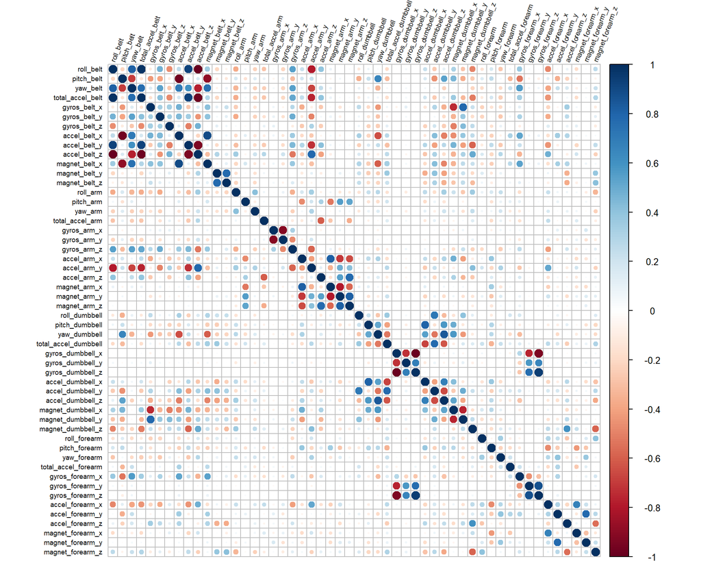

```r
        corrPlot <- cor(training[, -length(names(training))])
        corrplot(corrPlot, method="circle", tl.col="black", tl.cex=0.6, tl.srt=70)
```

### Model Selection.

It was decided to try 3x different training methods using the caret package to determine which might be best: * Gradient boosting using *GBM* method * Bagging using *treebag* method * Random forests using *rf* method * Random forests using *rf* method. This time run again with PCA in case there was any overfitting given the large number of variables

```r
        # library(randomForest)
        set.seed(33833)

        RFcontrol <- trainControl(method="cv", number=4, verboseIter = FALSE)

                        ## To measure time taken:
                        start.time <- Sys.time()
                        start.time
```

```
## [1] "2019-01-22 07:30:52 GMT"
```

```r
        modelfit <- train(classe ~ ., data=training, method="rf", trControl=RFcontrol, prox=TRUE, ntree=100)
        # modelfit
        Predict_RF <- predict(modelfit, testing)
        ConfMat_RF<-confusionMatrix(Predict_RF, as.factor(testing$classe))
        # ConfMat_RF # To see more detail
        ConfMat_RF$overall['Accuracy']
```

```
##  Accuracy
## 0.9935444
```

```r
                        ## To continue the time measurement
                        end.time <- Sys.time()
                        time.taken <- end.time - start.time
                        time.taken
```

```
## Time difference of 13.34201 mins
```

```r
        # library(randomForest)
        set.seed(33833)

        RF1control <- trainControl(method="cv", number=4, verboseIter = FALSE)

                        ## To measure time taken:
                        start.time <- Sys.time()
                        start.time
```

```
## [1] "2019-01-22 07:44:12 GMT"
```

```r
        modelfit1 <- train(classe ~ ., data=training, method="rf", preProcess = "pca", trControl=RF1control, prox=TRUE, ntree=100)
        # modelfit
        Predict_RF1 <- predict(modelfit1, testing)
        ConfMat_RF1<-confusionMatrix(Predict_RF1, as.factor(testing$classe))
        # ConfMat_RF # To see more detail
        ConfMat_RF1$overall['Accuracy']
```

```
##  Accuracy
## 0.9752187
```

```r
                        ## To continue the time measurement
                        end.time <- Sys.time()
                        time.taken <- end.time - start.time
                        time.taken
```

```
## Time difference of 10.05957 mins
```

[output not shown]

```r
        # library(gbm)
        # getModelInfo()$gbm$parameters
        set.seed(33833)

        GBMcontrol <- trainControl(method="repeatedcv", number=4, verboseIter = FALSE, repeats = 1)

                        ## To measure time taken:
                        start.time <- Sys.time()
                        start.time

       modelfit2 <- train(classe ~ ., data=training, method="gbm", trControl=GBMcontrol)



                        ## To continue the time measurement
                        end.time <- Sys.time()
                        time.taken <- end.time - start.time
                        time.taken
```

[output not shown]

```r
        # modelfit1
        Predict_GBM <- predict(modelfit2, testing)
        ConfMat_GBM<- confusionMatrix(Predict_GBM, as.factor(testing$classe))
        # ConfMat_GBM # To see more detail
        ConfMat_GBM$overall['Accuracy']
```

```
##  Accuracy
## 0.9652228
```

[output not shown]

```r
        # library(gbm)
        # getModelInfo()$gbm$parameters
        set.seed(33833)

                        ## To measure time taken:
                        start.time <- Sys.time()
                        start.time
```

```
## [1] "2019-01-22 07:58:40 GMT"
```

```r
        TBcontrol <- trainControl(method="repeatedcv", number=4, verboseIter = FALSE, repeats = 1)


       modelfit3 <- train(classe ~ ., data=training, method="treebag", trControl=TBcontrol)


        # modelfit1
        Predict_TB <- predict(modelfit3, testing)
        ConfMat_TB<- confusionMatrix(Predict_GBM, as.factor(testing$classe))
        # ConfMat_GBM # To see more detail
        ConfMat_TB$overall['Accuracy']
```

```
##  Accuracy
## 0.9652228
```

```r
                        ## To continue the time measurement
                        end.time <- Sys.time()
                        end.time
```

```
## [1] "2019-01-22 07:59:32 GMT"
```

```r
                        time.taken <- end.time - start.time
                        time.taken
```

```
## Time difference of 51.30943 secs
```

```r
         # names(getModelInfo()) # Gives a list of possible training methods in caret
        #getTree(modelfit$finalModel,k=2) # Use to select a particular tree result
```

[output not shown]

### Exercise Results

Predicting the test result based on the prediction results.

```r
        ## Carry out similar procedure for test data
        Predict_RF1 <- predict(modelfit, HAR_test_fin)
        Predict_RF2 <- predict(modelfit1, HAR_test_fin)
        Predict_GBM <- predict(modelfit2, HAR_test_fin)
        Predict_TB <- predict(modelfit3, HAR_test_fin)


        Predict_RF1;Predict_RF2;Predict_GBM;Predict_TB
```

```
##  [1] B A B A A E D B A A B C B A E E A B B B
## Levels: A B C D E
```

```
##  [1] B A B A A E D B A A B C B A E E A B B B
## Levels: A B C D E
```

```
##  [1] B A B A A E D B A A B C B A E E A B B B
## Levels: A B C D E
```

```
##  [1] B A B A A E D B A A B C B A E E A B B B
## Levels: A B C D E
```